# Tema 14. Coalescència

08/04/2025

## Població de Fisher-Wright

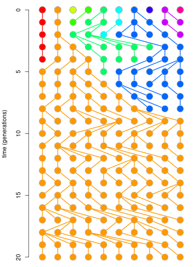

- La mida de la població, *N*, és finita i constant.
- A cada generació tots els individus (haploides) tenen la mateixa probabilitat de deixar descendència.
- Si la població és diploide, cada cercle representa una còpia del mateix gen.

## Coalescència

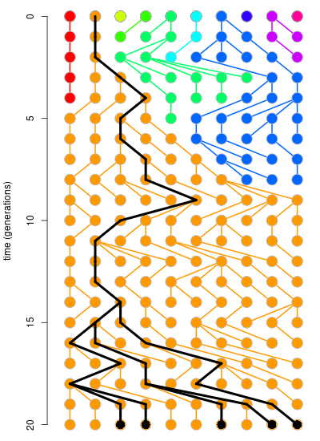

- Seleccionem una **mostra** d’individus de la població **actual**.
- Tracem la seua genealogia *remuntant-nos en el passat*, generació per generació.
- Retrocedint en el temps, els llinatges conflueixen: **coalescència**.
- El **MRCA** és l’ancestre comú **més recent** de la mostra.

## Coalescència

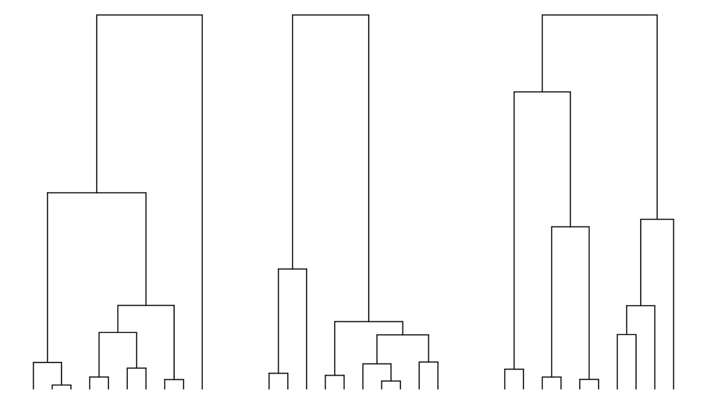

El procés *estocàstic* de la coalescència genera arbres amb una froma peculiar: amb una disminució de la *taxa de coalescència* cap al passat.

## Coalescència de dues seqüències

El **nombre de generacions** que hem de retrocedir en el passat per trobar l’ancestre comú de **dues** còpies d’un gen en una població de Fisher-Wright, \(T_2\), és una variable aleatòria amb una **distribució geomètrica**:

\(P(T_2 = j) = (1 - p)^{j-1} p\)

\(P(T_2 = j)\) és la probabilitat de què la coalescència es produïsca exactament *j* generacions en el passat. On *p* és la probabilitat de què la coalescència es produïsca en cada generació. Si la població és **haploide**:

\(p = \frac{1}{N}\)

és la probabilitat de què dues còpies d’un gen tinguen el mateix ancestre en la generació anterior. Per tant:

\(P(T_2=j) = \left(1 - \frac{1}{N}\right)^{j-1} \frac{1}{N}\)

## Coalescència de dues seqüències

| Ploidia | Paràmetre | \(P(T_2=j)\) | E\((T_2)\) | Var\((T_2)\) |
| --- | --- | --- | --- | --- |
| haploide | \(1/N\) | \(\left( 1 - \frac{1}{N}\right)^{j-1}\frac{1}{N}\) | N | \(N(N-1)\) |
| diploide | \(1/2N\) | \(\left( 1 - \frac{1}{2N}\right)^{j-1}\frac{1}{2N}\) | 2N | \(2N(2N-1)\) |

## En temps continu

La distribució geomètrica és *discreta*: només definida per valors enters de \(T_2\). Es pot aproximar amb la **distribució exponencial** (que és contínua), quan *N* és gran. En haploides:

\(P(T_2 > j) = \left(1-\frac{1}{N}\right)^j \simeq e^{-\frac{j}{N}}\)

\(P(T_2 \leq j) \simeq 1 - e^{-\frac{j}{N}}\)

En diploides:

\(P(T_2 > j) \simeq e^{-\frac{j}{2N}}\)

\(P(T_2 \leq j) \simeq 1 - e^{-\frac{j}{2N}}\)

## En temps continu

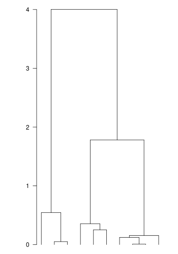

- Definim el **temps** continu: \(t = \frac{j}{N}\) en haploides, i \(t = \frac{j}{2N}\) en diploides.
- Una unitat de temps de coalescència és el nombre de generacions esperat fins la coalescència de dues seqüències: \(N\) generacions en haploides, i \(2N\) generacions en diploides.

## Mida poblacional efectiva

- Les poblacions reals es diferencien de les de Fisher-Wright.
- En lloc d’utilitzar la mida poblacional real, \(N\), utilitzem la **mida poblacional efectiva**, \(N_e\): mida d’una població de Fisher-Wright que experimentaria la mateixa quantitat de deriva que la població real.
- En avant, supose que la població és diploide amb mida efectiva \(N_e\).

## Coalescència entre *n* seqüències

Aproximació: màxim d’una coalescència entre dos llinatges per generació.

El temps (en generacions) que hem de retrocedir per trobar **la primera coalescència** entre *n* còpies d’un gen és una variable estocàstica amb distribució geomètrica.

La probabilitat de produir-se una coalescència entre dues còpies qualsevols d’entre una mostra d’*n* còpies d’un gen en la generació immediatament anterior, en una població diploide de mida efectiva \(N_e\) és:

\(p = {n \choose 2}\frac{1}{2N_e} = \frac{n(n-1)}{2}\cdot \frac{1}{2N_e}\)

Per tant:

\(P(T_n = j) = \left(1 - \frac{n(n-1)}{4N_e} \right)^{j-1} \cdot \frac{n(n-1)}{4N_e}\)

## Coalescència entre *n* seqüències

En **temps continu**, amb \(t = \frac{j}{2N_e}\):

\(P(T_n \leq t) = 1 - e^{-{n \choose 2}t} = 1 - e^{-\frac{n(n-1)t}{2}}\)

És a dir, el temps que ens hem de remuntar en el passat per tal que la genealogia de \(n\) llinatges es condense en \(n-1\) llinatges és aproximadament exponencial amb paràmetre \({n \choose 2}\).

\(f(t) = {n \choose 2}e^{-{n \choose 2}t}\), per \(t \geq 0\).

\(F(t) = P(T_n \leq t) = 1 - e^{-{n \choose 2} t}\), per \(t \geq 0\).

\(\mathrm{E}(t) = \frac{1}{{n \choose 2}} = \frac{2}{n(n-1)} \qquad\); \(\qquad \mathrm{var}(t) = \frac{1}{{n \choose 2}^2} = \left( \frac{2}{n(n-1)}\right)^2\)

## Coalescència entre *n* seqüències

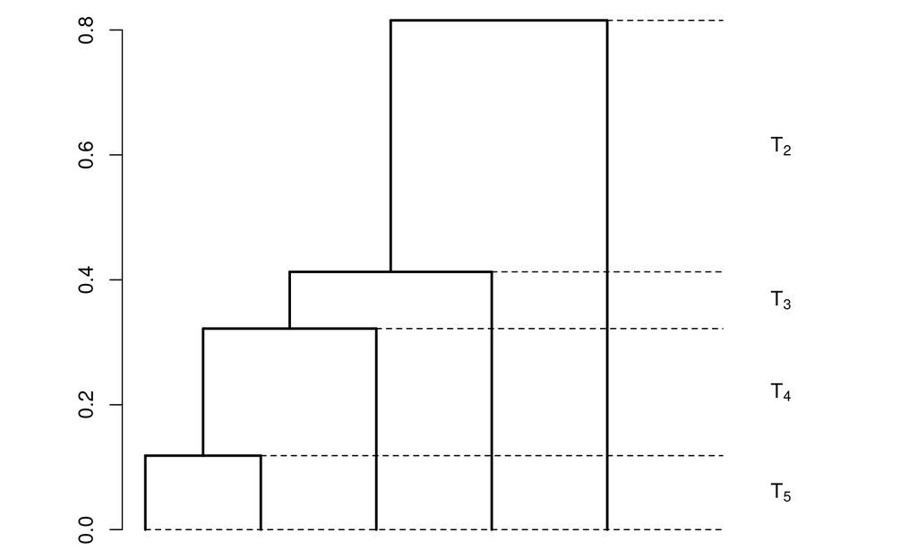

## Coalescència entre *n* seqüències

La mitjana de l’alçada total de l’arbre de coalescència entre \(n\) seqüències homòlogues és:

\(\mathrm{E}(H_n) = \sum_{k=2}^n \mathrm{E}(T_k) = \sum_{k=2}^n \frac{2}{k(k-1)} = 2\left( 1 - \frac{1}{n}\right) \approx 2\)

(Veure l’apèndix). En unitats de \(2N_e\) generacions en poblacions diploides, \(\mathrm{E}(H_n)\approx 4N_e\). Mentre que en poblacions haploides, 2 unitats de temps són \(2N_e\) generacions.

\(\mathrm{var}(H_n) = \sum_{k=2}^n\mathrm{var}(T_n) = 4\sum_{k=2}^n\frac{1}{k^2(k-1)^2}\)

## Apèndix

Per què \(\sum_{k=2}^n \frac{2}{k(k-1)} = 2\left(1 - \frac{1}{n}\right)\)?

\[ \sum_{k=2}^n \frac{2}{k(k-1)} = 2\cdot \sum_{k=2}^n \frac{1}{k(k-1)}\\ =2\cdot \sum_{k=2}^n \frac{k - (k - 1)}{k(k-1)}\\ =2\cdot \sum_{k=2}^n \left( \frac{k}{k(k-1)} - \frac{k-1}{k(k-1)}\right)\\ =2\cdot \sum_{k=2}^n \left( \frac{1}{k-1} - \frac{1}{k}\right)\\ =2\cdot \left( 1 - \frac{1}{2} + \frac{1}{2} - \frac{1}{3} + \frac{1}{3} - \frac{1}{4} +\ldots +\frac{1}{n-1} - \frac{1}{n}\right)\\ =2\cdot \left(1 - \frac{1}{n}\right) \]

## Bibliografia

- Hein, J., Schierup, M.H. i Wiuf, C. 2005. Gene genealogies, variation and evolution; a primer in coalescent theory. Oxford University Press.